# Attrition Analysis

Eric Cadena

7/29/2021

#Executive Summary DDS Analytics has provided an employee data set and wants to know the key factors leading to an employee leaving the Frito Lay company. After conducting Explanatory Data Analysis, Linear Regression models and creating a predictive model with a greater than 60% in Accuracy, Specificity and Sensitivity, it was concluded that being in a Manager role vs. a Non Manager role, Yearly Salary and Stock Option Levels were the biggest predictors of Attrition. If you are in a Non Manager role, earning under $50k a year, and you are not invested in the Company through Stock Options, there is a strong chance you will leave the Company. An interesting secondary finding is that relationships matter to attrition in the following way; if you have been with the same manager for over 2 years, you are likely to stay with the company and if you are a divorced employee you are more likely to stay with the company.

#Introduction The analysis was conducted using, heavy visualization for the purpose of conducting a thorough Explanatory Data Analysis while looking at the relationship between and among several variables. Once hints emerged as to the key factors leading to attrition, a linear regression model was implemented and prediction tests were run until a predictive model was built that could accurately tell us which factors can be identified an an employee that puts him at risk of leaving the company.

```r
#Packages used
library(tidyverse)
```

```r
library(ggplot2)
library(plotly)
library(class)
library(caret)
library(e1071)
library(plyr)
library(ROSE)
library(scales)
library(plotly)
library(data.table)
#Set up Primary Data Source in R
setwd('C:/Users/181429/Desktop/Semester 1 Courses/Doing Data Science/Unit 14 and 15 Case Study 2')  ## Set working directory
work <- read.csv("C:/Users/181429/Desktop/Semester 1 Courses/Doing Data Science/Unit 14 and 15 Case Study 2/CaseStudy2-data.csv", stringsAsFactors = TRUE, na.strings='..')
work = data.frame(work)
```

```r
#PART 1 OF THE ANALYSIS IS DATA TIDYING
#Change JobRole Cells to be more readable in a visual display
work = work%>%mutate(JobRole=as.character(JobRole))%>%mutate(JobRole = replace(JobRole, JobRole=='Sales Executive', 'Sale Exe'))%>%
  mutate(JobRole = replace(JobRole, JobRole=='Research Director', 'Res Dir'))%>%
  mutate(JobRole = replace(JobRole, JobRole=='Manufacturing Director', 'Man Dir'))%>%
  mutate(JobRole = replace(JobRole, JobRole=='Research Scientist', 'Res Sci'))%>%
  mutate(JobRole = replace(JobRole, JobRole=='Sales Representative', 'Sale Rep'))%>%
  mutate(JobRole = replace(JobRole, JobRole=='Healthcare Representative', 'Health Rep'))%>%
  mutate(JobRole = replace(JobRole, JobRole=='Manager', 'MGR'))%>%
  mutate(JobRole = replace(JobRole, JobRole=='Human Resources', 'HR'))%>%
  mutate(JobRole = replace(JobRole, JobRole=='Laboratory Technician', 'Lab Tech'))


#Create a yearly Salary column
#Creating Salary
work$Salary = work$MonthlyIncome*12

#Manager vs Not Manager
work1 <- within(work, MGR <- ifelse(JobRole=="Sale Exe","MANAGER",
ifelse(JobRole=="Lab Tech","NOT MANAGER",
ifelse(JobRole=="HR", "MANAGER",
ifelse(JobRole=="MGR","MANAGER",
ifelse(JobRole=="Health Rep", "NOT MANAGER",
ifelse(JobRole=="Sale Rep", "NOT MANAGER",
ifelse(JobRole=="Res Sci", "NOT MANAGER",
ifelse(JobRole=="Man Dir", "MANAGER",
ifelse(JobRole=="Res Dir", "MANAGER",NA))))))))))

#Creating Columns to create binary codes and categorize (Manager-1 vs Not Manager-0), (Single/Married-0 vs Divorced-1),
#(Attrition-0 vs Not-Attrition-1)
work2 <- within(work1, MGRcode<- ifelse(MGR=="MANAGER","1", ifelse(MGR=="NOT MANAGER","0",NA)))

work3 <- within(work2, Maritalcode<- ifelse(MaritalStatus=="Single","0",
ifelse(MaritalStatus=="Married","0",
ifelse(MaritalStatus=="Divorced","1", NA))))

work4 <- within(work3, Attritioncode<- ifelse(Attrition=="No","1", ifelse(Attrition=="Yes","0",NA)))

work5 <- within(work4, Stockcode <- ifelse(StockOptionLevel=="0","Not Invested",
ifelse(StockOptionLevel=="1","Sort of Invested",
ifelse(StockOptionLevel=="2","Invested",
ifelse(StockOptionLevel=="3","Really Invested",NA)))))

work6 <- within(work5, Timemgr <- ifelse(YearsWithCurrManager=="0","No Relationship",
ifelse(YearsWithCurrManager=="1","No Relationship",
ifelse(YearsWithCurrManager=="2","Some Relationship",
ifelse(YearsWithCurrManager=="3","Some Relationship",
ifelse(YearsWithCurrManager=="4","Some Relationship",
ifelse(YearsWithCurrManager=="5","Personal Relationship",
ifelse(YearsWithCurrManager=="6","Personal Relationship",
ifelse(YearsWithCurrManager=="7","Personal Relationship",
ifelse(YearsWithCurrManager=="8","Personal Relationship",
ifelse(YearsWithCurrManager=="9","Personal Relationship",
ifelse(YearsWithCurrManager=="10","Personal Relationship",
ifelse(YearsWithCurrManager=="11","Personal Relationship",
ifelse(YearsWithCurrManager=="12","Personal Relationship",
ifelse(YearsWithCurrManager=="13","Personal Relationship",
ifelse(YearsWithCurrManager=="14","Personal Relationship",
ifelse(YearsWithCurrManager=="15","Personal Relationship",
ifelse(YearsWithCurrManager=="16","Persoanl Relationship",
ifelse(YearsWithCurrManager=="17","Personal Relationship",NA)))))))))))))))))))

#Creating Salary Ranges
work7 <- within(work6, Range <- ifelse(Salary<50000, "0k-50k",
ifelse(Salary>50000 & Salary < 75000, "50k-75k",
ifelse(Salary>75000 & Salary < 100000, "75k-100k",
ifelse(Salary > 100000, ">100k", NA)))))


#Coding Salaries to conduct Statistics tests
work8 = within(work7, Range2 <- ifelse(Salary<=20000, "20",
ifelse(Salary>20000 & Salary<=25000, "25",
ifelse(Salary>25000 & Salary<=30000, "30",
ifelse(Salary>30000 & Salary<=35000, "35",
ifelse(Salary>35000 & Salary<=40000, "40",
ifelse(Salary>40000 & Salary<=45000, "45",
ifelse(Salary>45000 & Salary<=50000, "50",
ifelse(Salary>50000 & Salary<=55000, "55",
ifelse(Salary>55000 & Salary<=60000, "60",
ifelse(Salary>60000 & Salary<=65000, "65",
ifelse(Salary>65000 & Salary<=70000, "70",
ifelse(Salary>70000 & Salary<=75000, "75",
ifelse(Salary>75000, "80",NA))))))))))))))

#Coding Business Travel
work9 = within(work8, Travel <- ifelse(BusinessTravel=="Travel_Rarely","1",
ifelse(BusinessTravel=="Travel_Frequently","0",
ifelse(BusinessTravel=="Non-Travel","2",NA))))

#WE ARE NOT CONCERNED WITH THOSE HIRING EMPLOYEES and so we will Eliminate HR from the analysis.
##WE ARE NOT CONCERNED WITH THE TOP OF THE COMPANY HEIRARCHY
#On a side note, HR is an insignificant portion of those leaving the company
work10 = filter(work9, JobRole != "HR")
work10
```

```
##      ID Age Attrition    BusinessTravel DailyRate             Department
## 1     1  32        No     Travel_Rarely       117                  Sales
## 2     2  40        No     Travel_Rarely      1308 Research & Development
## 3     3  35        No Travel_Frequently       200 Research & Development
## 4     4  32        No     Travel_Rarely       801                  Sales
## 5     5  24        No Travel_Frequently       567 Research & Development
## 6     6  27        No Travel_Frequently       294 Research & Development
## 7     7  41        No     Travel_Rarely      1283 Research & Development
## 8     8  37        No     Travel_Rarely       309                  Sales
## 9     9  34        No     Travel_Rarely      1333                  Sales
## 10   10  34        No Travel_Frequently       653 Research & Development
## 11   11  43        No     Travel_Rarely       823 Research & Development
## 12   13  35        No     Travel_Rarely       950 Research & Development
## 13   14  30        No     Travel_Rarely       202                  Sales
## 14   16  31        No        Non-Travel      1188                  Sales
```

[output cut: 8425 more lines]

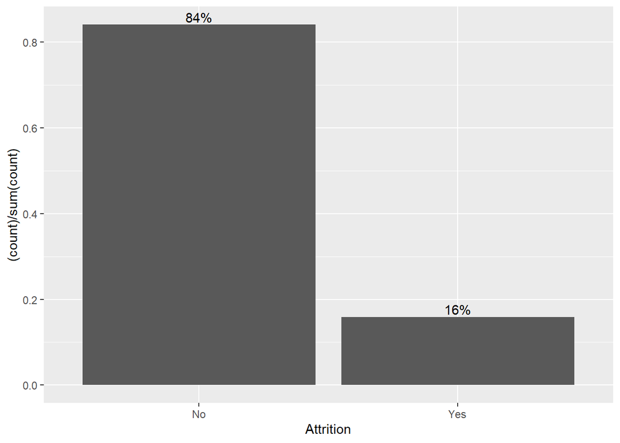

```r
#CONDUCT AND EXPLORATORY DATA ANALYSIS (EDA)
#Attrition Rate
ggplot(work10, aes(x=Attrition))+
  geom_bar(aes(y=(..count..)/sum(..count..)))+
  geom_text(aes(y=((..count..)/sum(..count..)),
        label=scales::percent((..count..)/sum(..count..))),
        stat="count",vjust=-0.25)
```

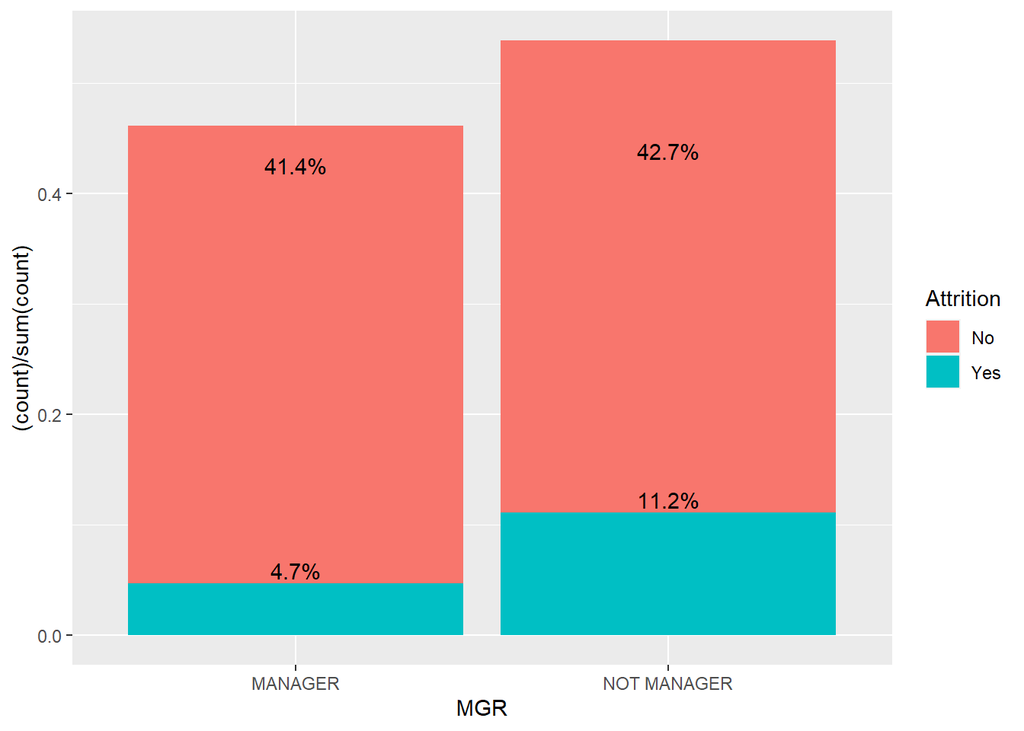

```r
#Attrition MGR vs Not Manager
ggplot(work10, aes(x=MGR, fill=Attrition))+
  geom_bar(aes(y=(..count..)/sum(..count..)))+
  geom_text(aes(y=((..count..)/sum(..count..)),
                label=scales::percent((..count..)/sum(..count..))),
            stat="count",vjust=-0.25)
```

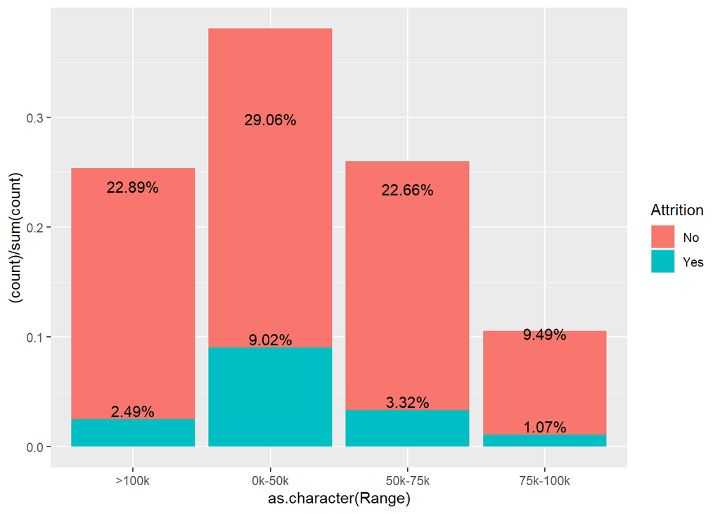

```r
#Salary and Attrition
ggplot(work10, aes(x=as.character(Range), fill=Attrition))+
  geom_bar(aes(y=(..count..)/sum(..count..)))+
  geom_text(aes(y=((..count..)/sum(..count..)),
                label=scales::percent((..count..)/sum(..count..))),
            stat="count",vjust=-0.25)
```

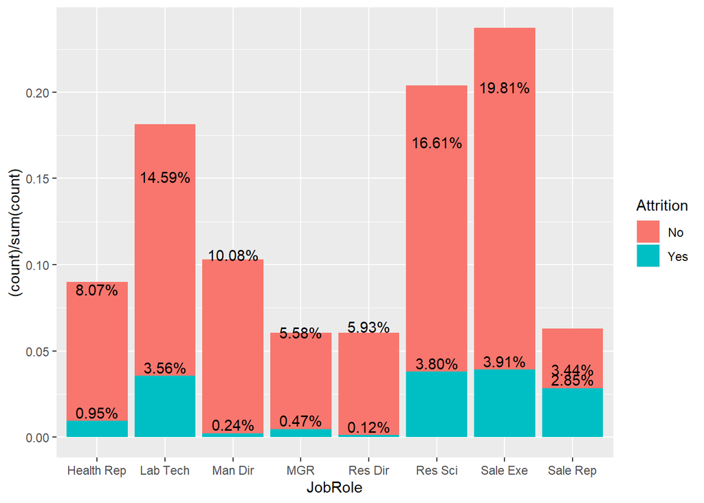

```r
#Job Role and Attrition
ggplot(work10, aes(x=JobRole, fill=Attrition))+
  geom_bar(aes(y=(..count..)/sum(..count..)))+
  geom_text(aes(y=((..count..)/sum(..count..)),
                label=scales::percent((..count..)/sum(..count..))),
            stat="count",vjust=-0.25)
```

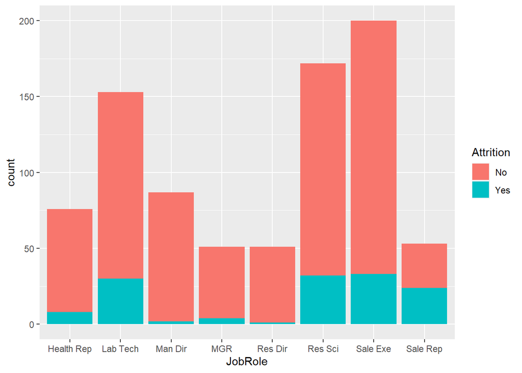

```r
#EDA showing relationship between Earnings and Job Role with a look at a variety of variables like Number of Companies Worked, Education, Stock Option Level, Years at Company,
#Years in Current Role, overtime, Sex, Marital Status, Business Travel & Department
ggplot(data=work10)+geom_bar(mapping=aes(x=JobRole, fill=Attrition))
```

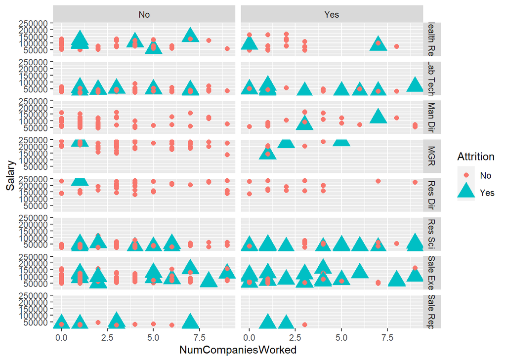

```r
ggplot(data=work10)+geom_point(mapping=aes(x=NumCompaniesWorked, y=Salary, color=Attrition, size=Attrition, shape=Attrition))+facet_grid(JobRole~OverTime)
```

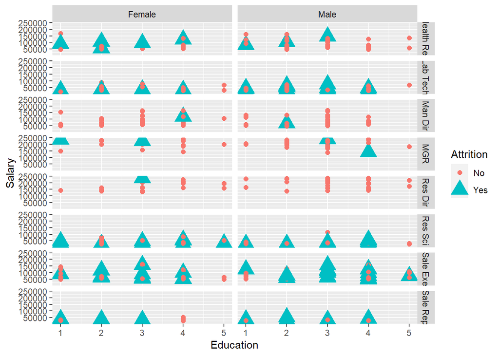

```r
ggplot(data=work10)+geom_point(mapping=aes(x=Education, y=Salary, color=Attrition, size=Attrition, shape=Attrition))+facet_grid(JobRole~Gender)
```

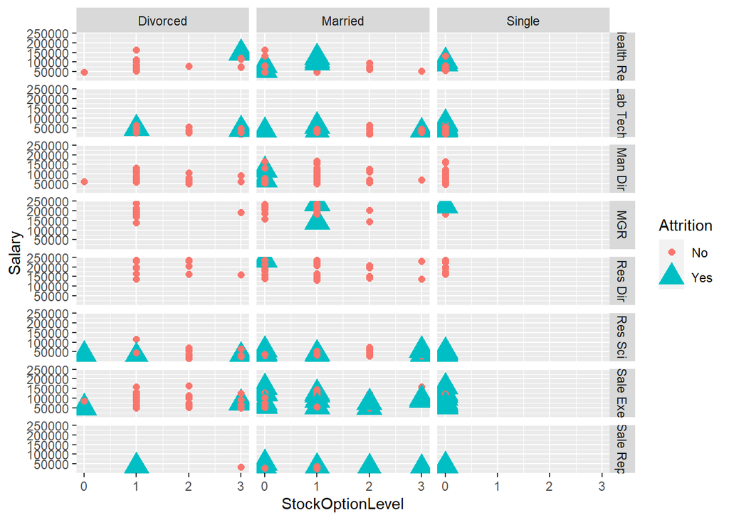

```r
ggplot(data=work10)+geom_point(mapping=aes(x=StockOptionLevel, y=Salary, color=Attrition, size=Attrition, shape=Attrition))+facet_grid(JobRole~MaritalStatus)
```

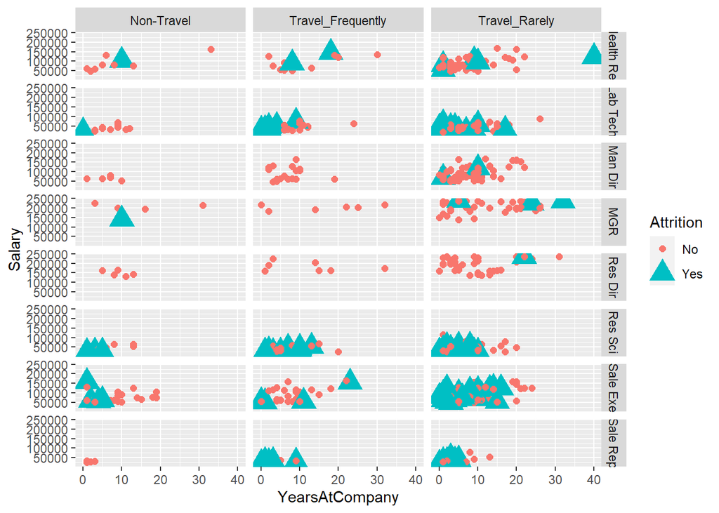

```r
ggplot(data=work10)+geom_point(mapping=aes(x=YearsAtCompany, y=Salary, color=Attrition, size=Attrition, shape=Attrition))+facet_grid(JobRole~BusinessTravel)
```

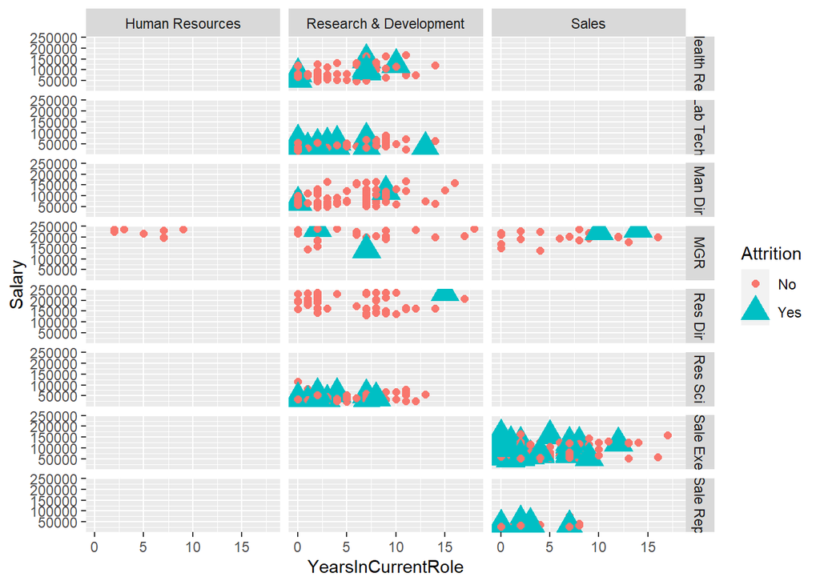

```r
ggplot(data=work10)+geom_point(mapping=aes(x=YearsInCurrentRole, y=Salary, color=Attrition, size=Attrition, shape=Attrition))+facet_grid(JobRole~Department)
```

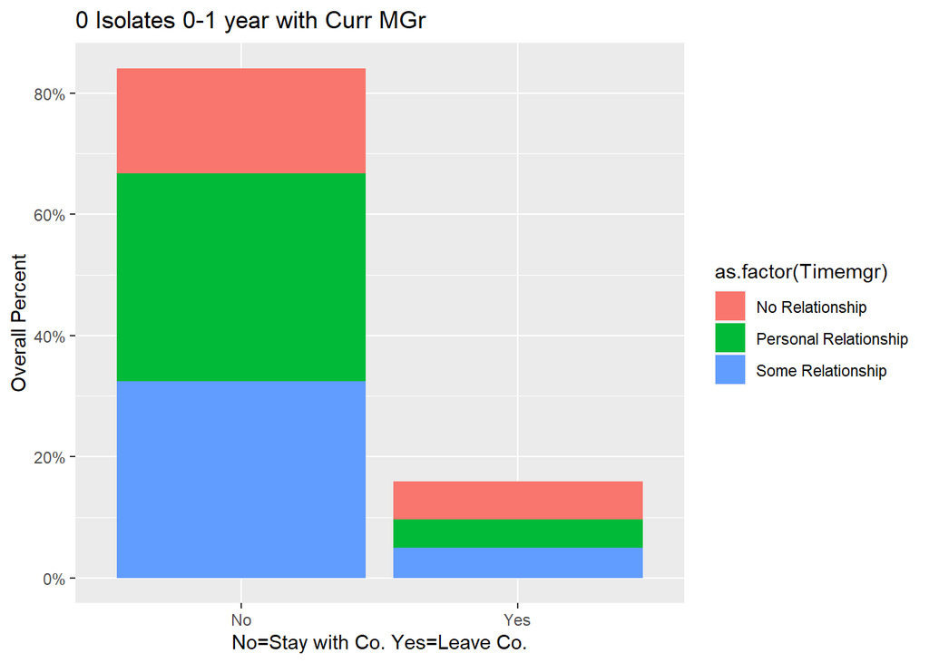

```r
#The data shows a clear relationship between the Job Role that leads to Attrition?


#EDA ON STAYING OR LEAVING IF YOU ARE IN A HIGH ATTRITION JOB BASED ON A VARIABLE OTHER THAN SALARY
#with current manager (*Postiive)
ggplot(work10, aes(x=factor(Attrition)))+geom_bar(aes(y=(..count..)/sum(..count..), fill=as.factor(Timemgr)))+
  scale_y_continuous(labels=percent)+xlab("No=Stay with Co. Yes=Leave Co.")+ylab("Overall Percent")+ggtitle("0 Isolates 0-1 year with Curr MGr")
```

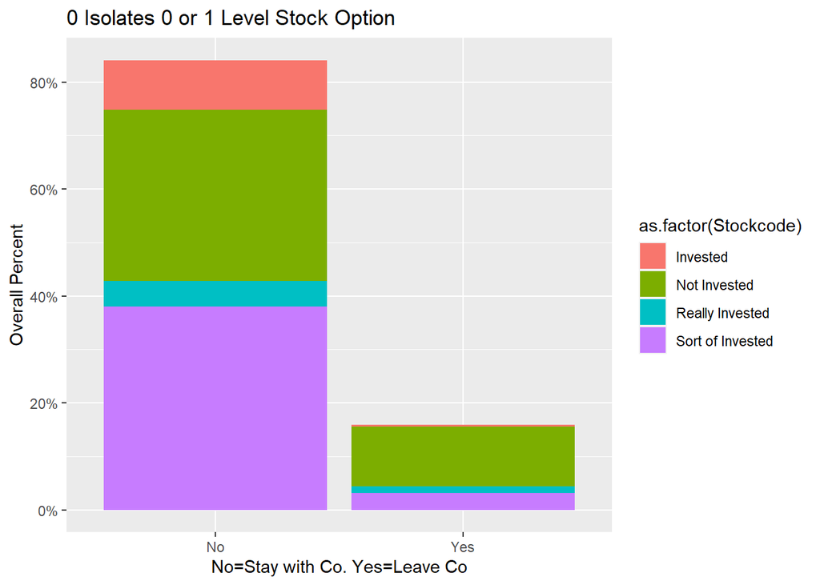

```r
#with stock options (*Positive)
ggplot(work10, aes(x=factor(Attrition)))+geom_bar(aes(y=(..count..)/sum(..count..), fill=as.factor(Stockcode)))+
  scale_y_continuous(labels=percent)+xlab("No=Stay with Co. Yes=Leave Co")+ylab("Overall Percent")+ggtitle("0 Isolates 0 or 1 Level Stock Option")
```

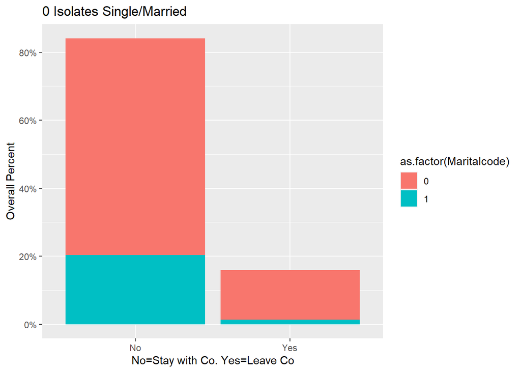

```r
#marital Status (*Positive)
ggplot(work10, aes(x=factor(Attrition)))+geom_bar(aes(y=(..count..)/sum(..count..), fill=as.factor(Maritalcode)))+
  scale_y_continuous(labels=percent)+xlab("No=Stay with Co. Yes=Leave Co")+ylab("Overall Percent")+ggtitle("0 Isolates Single/Married")
```

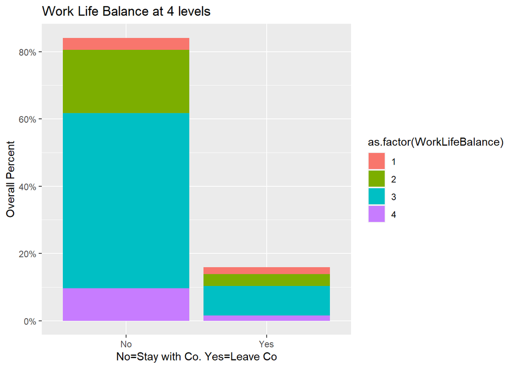

```r
#with work life balance (*Even employees happy with this are leaving)
ggplot(work10, aes(x=factor(Attrition)))+geom_bar(aes(y=(..count..)/sum(..count..), fill=as.factor(WorkLifeBalance)))+
  scale_y_continuous(labels=percent)+xlab("No=Stay with Co. Yes=Leave Co")+ylab("Overall Percent")+ggtitle("Work Life Balance at 4 levels")
```

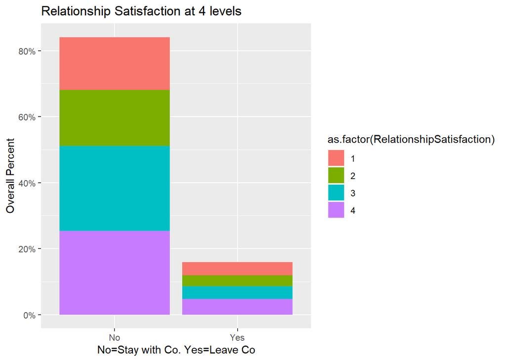

```r
#Relationship Satisfaction (*Not a Factor)
ggplot(work10, aes(x=factor(Attrition)))+geom_bar(aes(y=(..count..)/sum(..count..), fill=as.factor(RelationshipSatisfaction)))+
  scale_y_continuous(labels=percent)+xlab("No=Stay with Co. Yes=Leave Co")+ylab("Overall Percent")+ggtitle("Relationship Satisfaction at 4 levels")
```

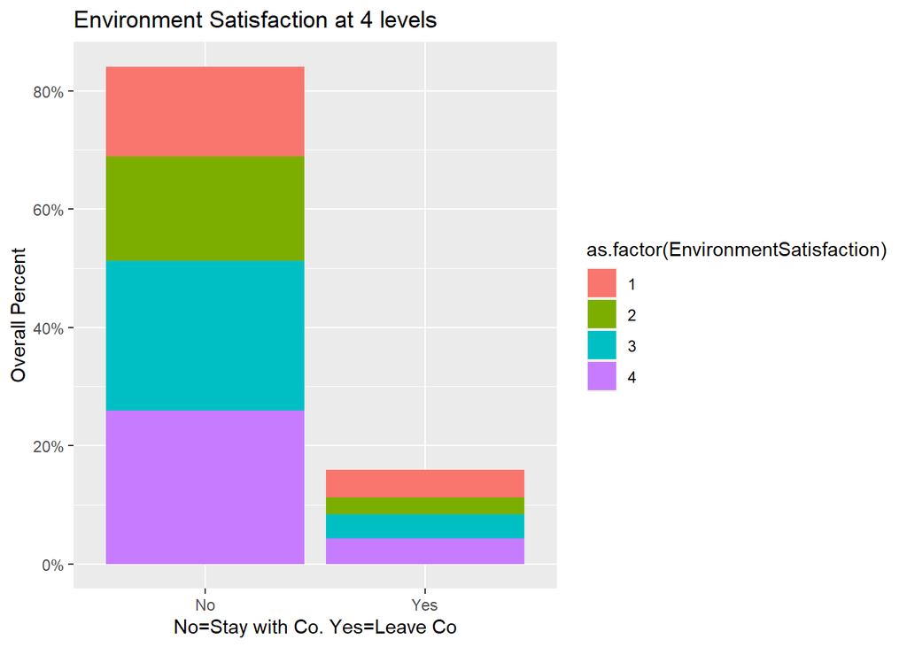

```r
#Environment Satisfaction (*Even employees happy with this are leaving)
ggplot(work10, aes(x=factor(Attrition)))+geom_bar(aes(y=(..count..)/sum(..count..), fill=as.factor(EnvironmentSatisfaction)))+
  scale_y_continuous(labels=percent)+xlab("No=Stay with Co. Yes=Leave Co")+ylab("Overall Percent")+ggtitle("Environment Satisfaction at 4 levels")
```

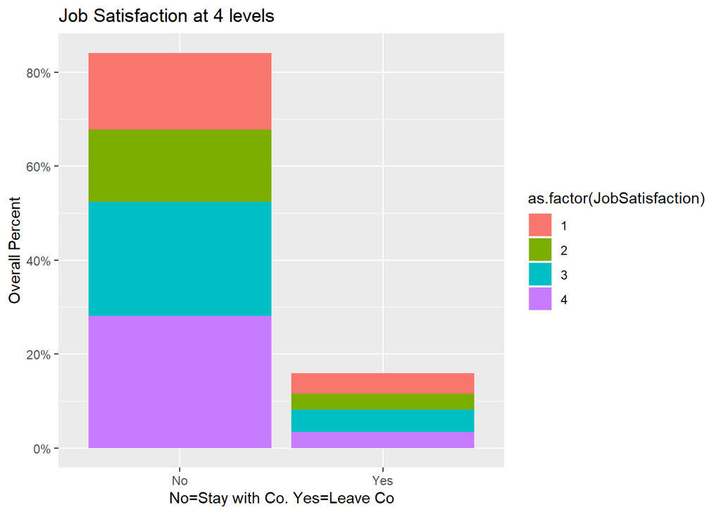

```r
#Job Satisfaction  (*Not a Factor)
ggplot(work10, aes(x=factor(Attrition)))+geom_bar(aes(y=(..count..)/sum(..count..), fill=as.factor(JobSatisfaction)))+
  scale_y_continuous(labels=percent)+xlab("No=Stay with Co. Yes=Leave Co")+ylab("Overall Percent")+ggtitle("Job Satisfaction at 4 levels")
```

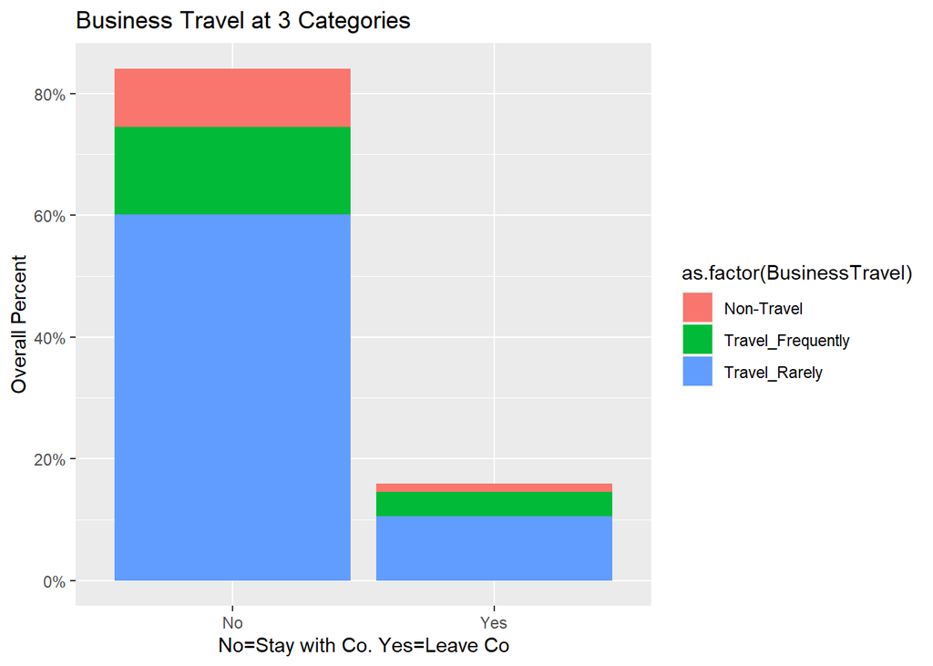

```r
#Business Travel (*Not a Factor)
ggplot(work10, aes(x=factor(Attrition)))+geom_bar(aes(y=(..count..)/sum(..count..), fill=as.factor(BusinessTravel)))+
  scale_y_continuous(labels=percent)+xlab("No=Stay with Co. Yes=Leave Co")+ylab("Overall Percent")+ggtitle("Business Travel at 3 Categories")
```

```r
#WE ARE READY TO CREATE A MODEL USING FOUR VARIABLES DISCOVERED IN THE EDA THAT WE THINK IMPACTS THE DECISION TO LEAVE THE COMPANY
#Isolating the columns we want to use to build the model
Attrition = select(work10, MGR,MaritalStatus, Stockcode,Range,BusinessTravel, Timemgr, Attrition)
Attrition
```

```
##             MGR MaritalStatus        Stockcode    Range    BusinessTravel
## 1       MANAGER      Divorced Sort of Invested  50k-75k     Travel_Rarely
## 2       MANAGER        Single     Not Invested    >100k     Travel_Rarely
## 3       MANAGER        Single     Not Invested    >100k Travel_Frequently
## 4       MANAGER       Married         Invested    >100k     Travel_Rarely
## 5   NOT MANAGER        Single     Not Invested   0k-50k Travel_Frequently
## 6       MANAGER      Divorced         Invested    >100k Travel_Frequently
## 7   NOT MANAGER       Married     Not Invested   0k-50k     Travel_Rarely
## 8       MANAGER      Divorced  Really Invested 75k-100k     Travel_Rarely
## 9   NOT MANAGER       Married Sort of Invested   0k-50k     Travel_Rarely
## 10  NOT MANAGER       Married Sort of Invested  50k-75k Travel_Frequently
## 11      MANAGER       Married     Not Invested    >100k     Travel_Rarely
## 12      MANAGER        Single     Not Invested    >100k     Travel_Rarely
## 13  NOT MANAGER       Married Sort of Invested   0k-50k     Travel_Rarely
## 14      MANAGER       Married Sort of Invested 75k-100k        Non-Travel
```

[output cut: 1673 more lines]

```r
summary(Attrition)
```

```
##      MGR             MaritalStatus  Stockcode            Range
##  Length:843         Divorced:183   Length:843         Length:843
##  Class :character   Married :397   Class :character   Class :character
##  Mode  :character   Single  :263   Mode  :character   Mode  :character
##            BusinessTravel   Timemgr          Attrition
##  Non-Travel       : 92    Length:843         No :709
##  Travel_Frequently:155    Class :character   Yes:134
##  Travel_Rarely    :596    Mode  :character
```

```r
#Data Partition
set.seed(123)
ind = sample(seq(1:length(Attrition$Attrition)),round(.7*length(Attrition$Attrition)))
train = Attrition[ind,]
test = Attrition[-ind,]

model = naiveBayes(Attrition ~ MGR + MaritalStatus + Stockcode + Range + Timemgr, data=train)
confusionMatrix(predict(model,test), test$Attrition)
```

```
## Confusion Matrix and Statistics
##
##           Reference
## Prediction  No Yes
##        No  199  25
##        Yes  12  17
##
##                Accuracy : 0.8538
##                  95% CI : (0.8041, 0.8949)
##     No Information Rate : 0.834
##     P-Value [Acc > NIR] : 0.22592
##
##                   Kappa : 0.3971
##
##  Mcnemar's Test P-Value : 0.04852
##
##             Sensitivity : 0.9431
##             Specificity : 0.4048
##          Pos Pred Value : 0.8884
##          Neg Pred Value : 0.5862
##              Prevalence : 0.8340
##          Detection Rate : 0.7866
##    Detection Prevalence : 0.8854
##       Balanced Accuracy : 0.6739
##
##        'Positive' Class : No
##
```

```r
#Over Sample
over <- ovun.sample(Attrition~.,data=train, method="over",N=998)$data
table(over$Attrition)
```

```
##
##  No Yes
## 498 500
```

```r
model2 = naiveBayes(Attrition ~ MGR + MaritalStatus + Stockcode + Range, data = over)
confusionMatrix(predict(model2,test), test$Attrition)
```

```
## Confusion Matrix and Statistics
##
##           Reference
## Prediction  No Yes
##        No  136  16
##        Yes  75  26
##
##                Accuracy : 0.6403
##                  95% CI : (0.5778, 0.6995)
##     No Information Rate : 0.834
##     P-Value [Acc > NIR] : 1
##
##                   Kappa : 0.1687
##
##  Mcnemar's Test P-Value : 1.201e-09
##
##             Sensitivity : 0.6445
##             Specificity : 0.6190
##          Pos Pred Value : 0.8947
##          Neg Pred Value : 0.2574
##              Prevalence : 0.8340
##          Detection Rate : 0.5375
##    Detection Prevalence : 0.6008
##       Balanced Accuracy : 0.6318
##
##        'Positive' Class : No
##
```

```r
#Saving csv prediction file for Attrition
A = predict(model2,test)
A
```

```
##   [1] No  Yes Yes No  Yes No  Yes No  Yes No  Yes No  Yes No  No  No  Yes No
##  [19] Yes No  Yes Yes Yes No  Yes No  Yes Yes Yes No  Yes No  No  Yes Yes Yes
##  [37] Yes No  No  No  No  Yes No  No  No  No  No  No  No  Yes No  Yes No  No
##  [55] No  No  No  Yes No  No  Yes No  No  Yes No  No  No  Yes No  No  No  No
##  [73] No  No  No  No  Yes No  No  No  Yes Yes No  No  Yes No  No  Yes Yes No
##  [91] No  No  No  Yes No  No  Yes Yes Yes No  No  No  No  Yes Yes No  No  Yes
## [109] Yes No  No  Yes No  No  Yes No  No  No  No  No  No  Yes Yes No  Yes No
## [127] Yes No  Yes No  Yes No  Yes Yes No  Yes No  Yes Yes Yes No  No  No  Yes
## [145] No  No  No  Yes Yes No  No  Yes No  No  No  No  No  No  No  Yes Yes No
## [163] No  Yes Yes No  No  No  No  No  No  Yes No  Yes No  Yes No  No  No  Yes
## [181] No  Yes Yes Yes Yes Yes No  No  No  No  Yes Yes No  No  No  Yes No  No
## [199] No  Yes Yes Yes Yes No  Yes Yes No  Yes Yes No  No  Yes No  Yes No  Yes
## [217] Yes No  No  Yes No  Yes No  Yes Yes Yes No  Yes No  No  No  No  Yes Yes
## [235] Yes No  No  No  Yes No  No  No  No  No  No  No  Yes Yes No  Yes No  No
## [253] No
## Levels: No Yes
```

```r
A1=data.frame(A)

setDT(A1, keep.rownames=TRUE)[]
```

```
##       rn   A
##   1:   1  No
##   2:   2 Yes
##   3:   3 Yes
##   4:   4  No
##   5:   5 Yes
##  ---
## 249: 249  No
## 250: 250 Yes
## 251: 251  No
## 252: 252  No
## 253: 253  No
```

```r
A2 = setNames(A1, c("ID","Attrition"))
A2
```

```
##       ID Attrition
##   1:   1        No
##   2:   2       Yes
##   3:   3       Yes
##   4:   4        No
##   5:   5       Yes
##  ---
## 249: 249        No
## 250: 250       Yes
## 251: 251        No
## 252: 252        No
## 253: 253        No
```

```r
write.csv(A2, file="C:/Users/181429/Desktop/Semester 1 Courses/Doing Data Science/Unit 14 and 15 Case Study 2//Case2PredicitonsCadenaAttrition.csv", row.names=FALSE)
```

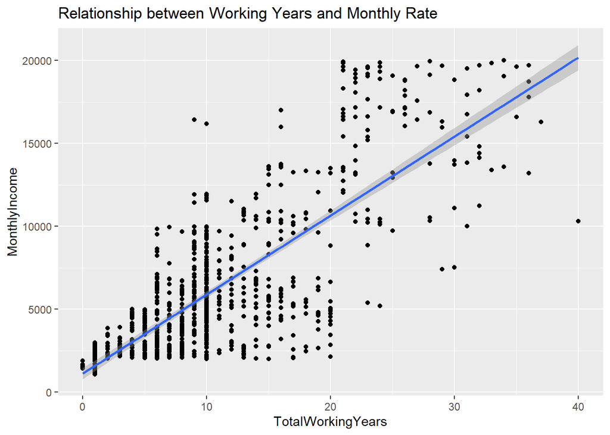

```r
#WHAT IS AN EMPLOYEE MOST LIKELY TO MAKE
#Find a relationship between the response variable Income and an explanatory variable
work9%>%ggplot(aes(x=TotalWorkingYears, y=MonthlyIncome))+geom_point()+ggtitle("Relationship between Working Years and Monthly Rate")+geom_smooth(method="lm")
```

```r
work11 = select(work9,ID, MonthlyIncome, TotalWorkingYears, JobLevel)


#Multiple Linear Regression
set.seed(123)
ind = sample(seq(1:length(work11$MonthlyIncome)),round(.7*length(work11$MonthlyIncome)))
train = work11[ind,]
test = work11[-ind,]

M = lm(MonthlyIncome~TotalWorkingYears+factor(JobLevel), data=train)
M
```

```
##
## Call:
## lm(formula = MonthlyIncome ~ TotalWorkingYears + factor(JobLevel),
##     data = train)
##
## Coefficients:
##       (Intercept)  TotalWorkingYears  factor(JobLevel)2  factor(JobLevel)3
##           2585.92              33.64            2608.83            6951.45
## factor(JobLevel)4  factor(JobLevel)5
##          11937.02           15689.08
```

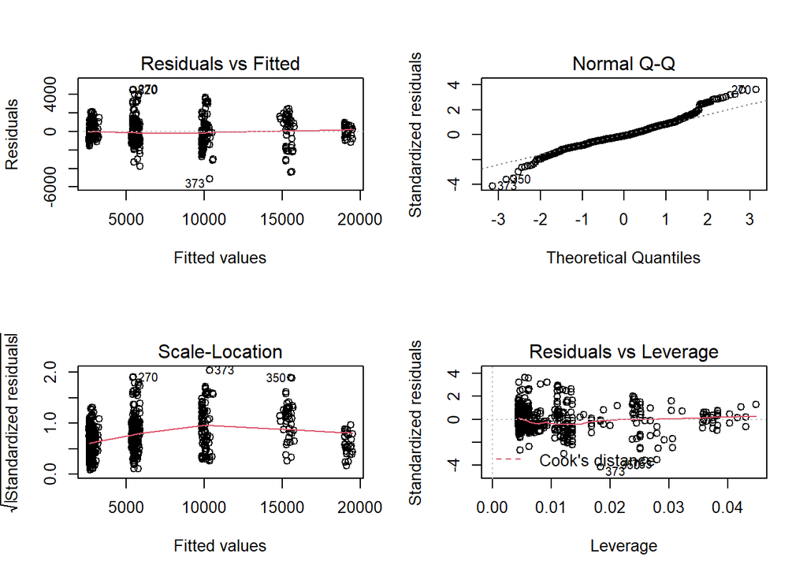

```r
par(mfrow=c(2,2))
plot(M)
```

```r
p2 = predict(M,test)
error = test$MonthlyIncome-p2
RMSE = sqrt(mean(error^2))
RMSE
```

```
## [1] 1272.803
```

```r
p2
```

```
##         1         3         4         7         9        12        15        17
##  5463.895  9873.800 10008.369  2821.420  2619.565  2686.850  2922.347  5463.895
##        18        22        25        27        28        32        35        42
##  5430.252  5598.464  5396.610  5531.179  5396.610  3056.916  5463.895  5497.537
##        43        44        50        53        56        58        60        62
##  3157.844 19082.420  2787.777  2922.347  2754.135  2922.347  2619.565  9873.800
##        63        66        68        70        75        77        82        86
##  2686.850  2821.420  2754.135  3157.844  9873.800  9873.800  5766.676 15532.210
##        92        93        97        99       101       102       107       109
##  9907.442  2821.420 15296.713  2720.492  2787.777  9974.727  5531.179  5632.107
##       114       123       126       133       140       142       144       145
##  5733.034 10142.939  5531.179  5430.252  9941.084  2653.207  5430.252  5699.391
##       146       147       149       150       154       157       172       173
##  5329.325  2855.062  2787.777  5396.610  5564.822  5699.391  5733.034 10479.363
##       176       182       183       192       194       198       208       213
##  2653.207  5564.822  3191.486  9840.157  5665.749 15263.071  5766.676  2720.492
##       214       215       216       230       233       245       247       248
##  5463.895  2754.135  2855.062 15532.210 15363.998  5531.179  9907.442  2686.850
##       249       253       254       256       257       266       269       272
##  5598.464  2619.565  2653.207  2821.420  2653.207  2787.777  5497.537  5564.822
##       274       285       293       300       307       312       313       314
##  5564.822  2821.420  2821.420  2754.135  2855.062 15263.071  2821.420  5531.179
##       318       320       321       325       327       332       333       335
##  5329.325  2619.565  2754.135 15229.429 19048.777 10008.369  2787.777 19284.274
##       341       353       354       356       359       360       363       365
##  2787.777  5733.034  5463.895  5699.391  5497.537  3124.201 19385.201 19048.777
##       366       368       369       370       372       376       380       387
## 15734.065  5497.537  2720.492  5531.179  9873.800 15599.495  2821.420  9873.800
##       394       405       406       407       411       414       416       419
## 10277.508  2787.777 15229.429  5632.107  2787.777  5329.325  5699.391  5665.749
##       423       425       432       433       434       435       438       439
##  5598.464  5362.967  2787.777  5867.604  2619.565  9907.442  2855.062  2686.850
##       440       441       442       443       448       449       453       469
##  5531.179  5531.179  2888.704  2754.135  5531.179  5531.179  5531.179  5430.252
##       470       481       485       486       488       489       492       495
##  5362.967  5396.610 10883.072  5463.895  2754.135 10311.151 15363.998  5531.179
##       497       501       502       503       505       506       507       510
##  2855.062 10580.290  2787.777  3225.128 15397.641  5598.464  2619.565 19048.777
##       511       512       513       514       517       521       525       527
##  5531.179  9974.727  2922.347 10042.012  2619.565  2787.777  2821.420  5497.537
```

[output cut: 11 more lines]

```
## 15734.065  5362.967  2922.347  5531.179  2619.565  3023.274  5531.179  9873.800
##       694       695       697       699       701       704       705       710
##  2686.850  5396.610 15296.713  2585.923  2619.565  2787.777  2821.420 15565.853
##       718       720       723       725       730       732       742       754
##  5531.179  9873.800  2922.347  2855.062  2686.850  5598.464  9873.800 10008.369
##       757       759       762       764       767       771       772       777
##  5531.179  2821.420 15397.641  5833.961  2922.347  5497.537 10344.793  2787.777
##       778       784       790       792       794       796       798       804
##  2619.565  5531.179  2653.207  2888.704 10109.296  2922.347  2619.565  9840.157
##       805       806       807       811       814       822       826       828
##  5766.676 10042.012  5396.610  5598.464 19183.347  5531.179 19048.777  5329.325
##       831       837       838       841       850       855       857       858
##  5497.537  2855.062  5531.179  2585.923  2855.062  5329.325  2855.062  9873.800
##       860       864       865       867       868
##  9873.800 15464.926  9873.800  5329.325  5564.822
```

```r
#Saving csv prediction file for Monthly Income
p3=data.frame(p2)
p3
```

```
##            p2
## 1    5463.895
## 3    9873.800
## 4   10008.369
## 7    2821.420
## 9    2619.565
## 12   2686.850
## 15   2922.347
## 17   5463.895
## 18   5430.252
## 22   5598.464
## 25   5396.610
## 27   5531.179
## 28   5396.610
## 32   3056.916
```

[output cut: 247 more lines]

```r
setDT(p3, keep.rownames=TRUE)[]
```

```
##       rn        p2
##   1:   1  5463.895
##   2:   3  9873.800
##   3:   4 10008.369
##   4:   7  2821.420
##   5:   9  2619.565
##  ---
## 257: 860  9873.800
## 258: 864 15464.926
## 259: 865  9873.800
## 260: 867  5329.325
## 261: 868  5564.822
```

```r
p4 = setNames(p3, c("ID","MonthlyIncome"))
p4
```

```
##       ID MonthlyIncome
##   1:   1      5463.895
##   2:   3      9873.800
##   3:   4     10008.369
##   4:   7      2821.420
##   5:   9      2619.565
##  ---
## 257: 860      9873.800
## 258: 864     15464.926
## 259: 865      9873.800
## 260: 867      5329.325
## 261: 868      5564.822
```

```r
write.csv(p4, file="C:/Users/181429/Desktop/Semester 1 Courses/Doing Data Science/Unit 14 and 15 Case Study 2//Case2PredicitonsCadenaSalary.csv", row.names=FALSE)
```